# SMEs Scaling up in Croatia: Country note

OECD, Centre for Entrepreneurship, SMEs, Regions and Cities (CFE)

2024-04-12

## Scalers and the economy

*A small group of SMEs that grow fast over a short period of time, i.e. “scalers”, provide a large part of the growth in jobs and economic value in OECD countries. This section contains an overview of the recent trends in the number of scalers in Croatia and benchmark their contributions to job and value creation with other countries.*

### Around 28% of Croatian SMEs are scalers

In Croatia, about 3 900 small or medium-sized enterprises (SMEs) became scalers between 2018 and 2021, accounting for 28% of the 14 000 SMEs in the non-financial business sector. Among those, about 2 000 were scalers in employment, 3 200 were scalers in turnover, and 1 300 were scalers in both employment and turnover.

Scalers in year 2020 are defined as enterprises with 10 to 249 employees (SMEs) that increased employment or turnover by at least 10% per year, on average, over the three previous years (2017-20). This means they grow by at least 33% over the three-year period.

High-growth scalers, defined as SMEs with annual growth rates exceeding 20% over three consecutive years, may exhibit distinct trends through economic cycles. Compared to other scalers, high-growth scalers may be faster to react to economic shifts and new market opportunities, but they may also be more constrained by lack of financial resources or tight labour markets. About one in three scalers grows by more than 20% per year on average over three consecutive years, qualifying as “high-growth” scalers. In 2021, there were 600 high-growth scalers in employment and 1 400 high-growth scalers in turnover. The number of high-growth employment and scalers in turnover has been gradually increasing over time before the onset of the COVID-19 pandemic, reaching a peak of 1 500 for scalers in turnover and 700 for scalers in employment in 2019.

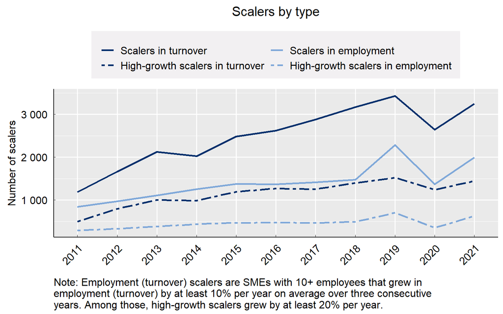

### Scalers in employment created 26 000 jobs over three years

In Croatia, scalers in employment created 26 000 jobs over the 2017-20 period, which accounts to 6.7 jobs for every 100 workers in SMEs in 2017. Croatia belongs to the group of countries in which scalers in employment made a relatively small contribution to job creation by SMEs. The group also includes Slovak Republic, Austria and Estonia.

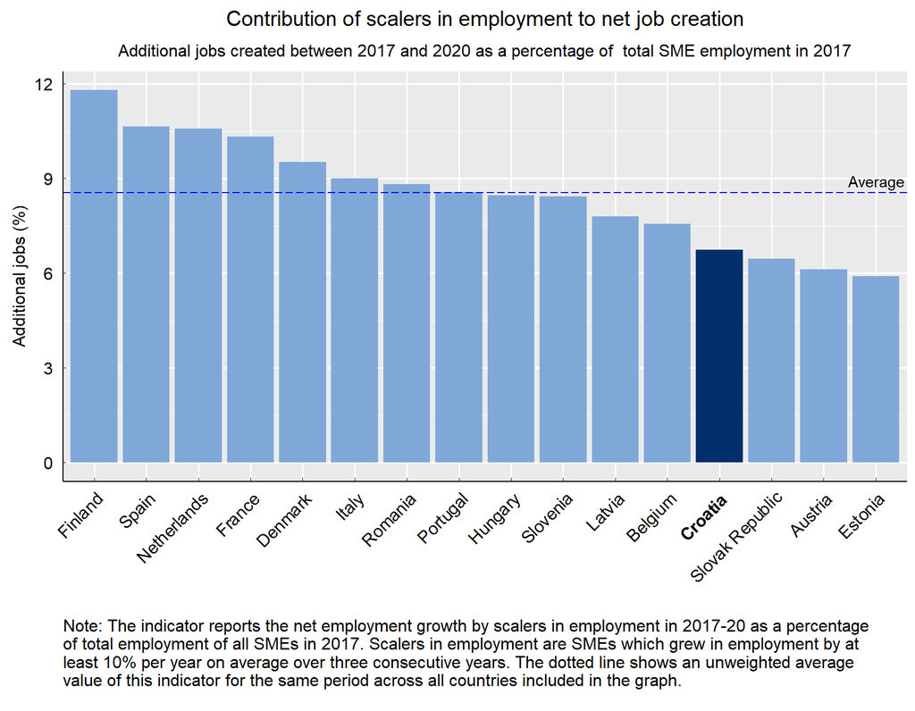

### The contribution of scalers in turnover was above the average of other countries

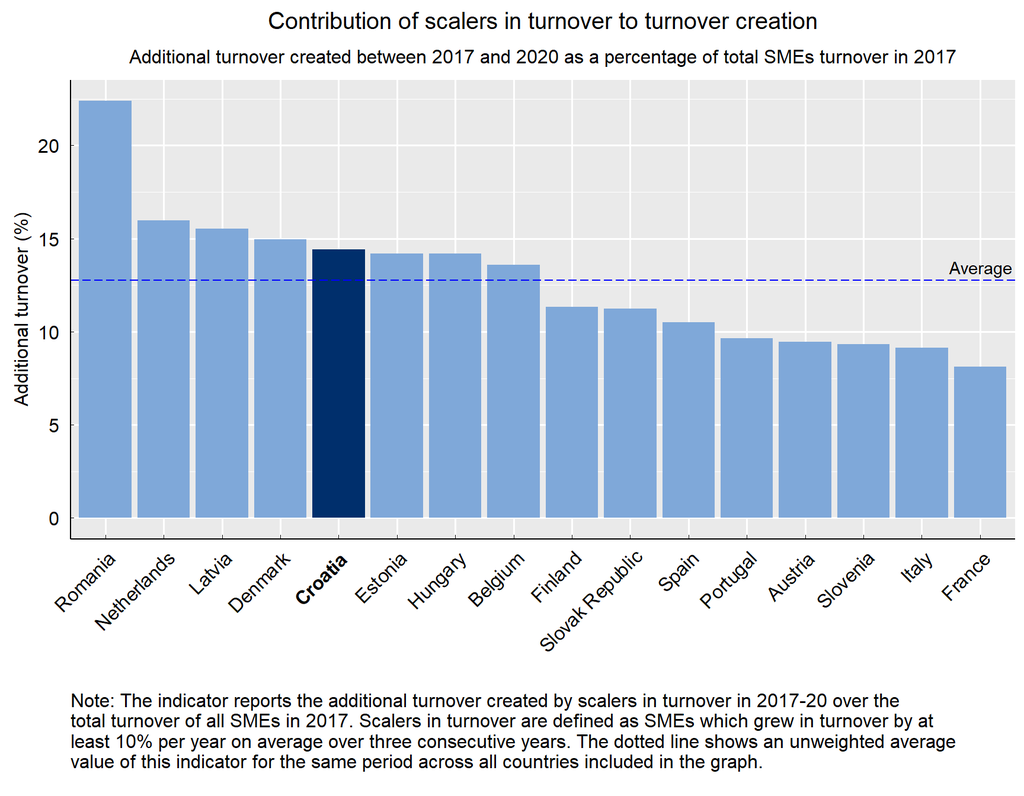

## Scalers’ characteristics

*All types of SMEs can scale up. This section describes the characteristics of scalers in terms of sector of activity, size, age, and geographical distribution. It also compares the likelihood of SMEs to scale up in Croatia and in other countries across different groups of SMEs.*

### Croatian SMEs operating in construction and in advanced services are more likely to scale up

Most Croatian scalers operate in non-tradable services, construction, or medium-low tech manufacturing and extractive industries (23%, 21%, and 19%, respectively). The distribution of scalers across economic activities mirrors largely the distribution of SMEs across these activities.

However, in certain sectors scalers are overrepresented, particularly in the construction sector, which comprise 21% of scalers but 14% of all SMEs. This reflects the higher probability of SMEs to scale up in these sectors. About 43% of SMEs in the construction sector become scalers, compared to 20% in the other tradable services sector. Relative to other countries, Croatian SMEs have a higher likelihood to become scalers in the construction sector and, to a lower extent, also in manufacturing.

Sector groups include the following two-digit NACE sectors:

• Low and medium-low technology manufacturing and extractive industries: food, textile, paper, wood, refined petroleum, rubber, plastic, basic metal products, mining.

• Medium-high and high technology manufacturing: chemical products, pharmaceuticals, computer, electronic/electrical equipment, machinery, transport equipment.

• Advanced tradable services: software, telecommunications, consultancy, legal services, accounting services, architectural activities, scientific research.

• Other tradable services: travel agency, services to buildings/landscape, employment activities, veterinary, accommodation/food services, services for transportation.

• Other non-tradable services: electricity, gas and water supply, waste management, wholesale and retail trade, repair of motor vehicles/household goods, real estate activities.

• Education, social care and health services: Education, human health activities, residential care, social work.

• Construction: construction of buildings, civil engineering, specialised construction activities.

Source: Manufacturing sectors are aggregated using Eurostat’s high-technology classification of manufacturing industries. The classification of tradable and non-tradable services is based on Piton, S. (2021). Economic integration and unit labour costs. European Economic Review, 136, 103746.

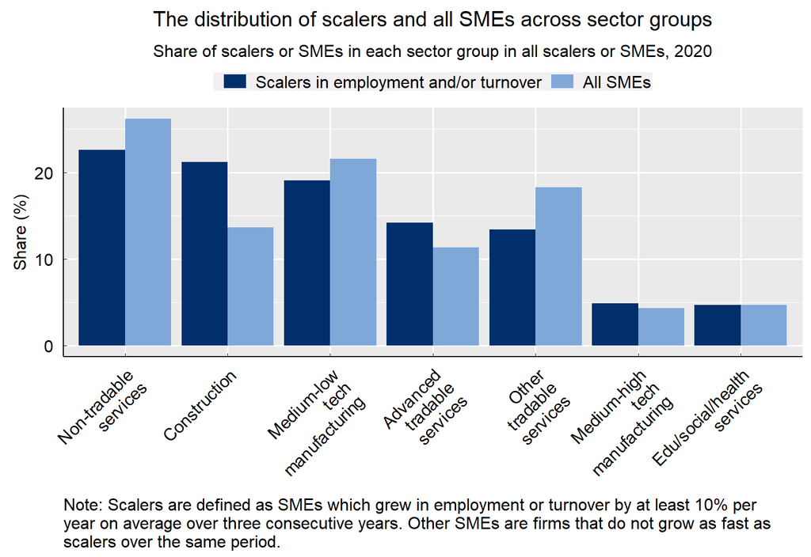

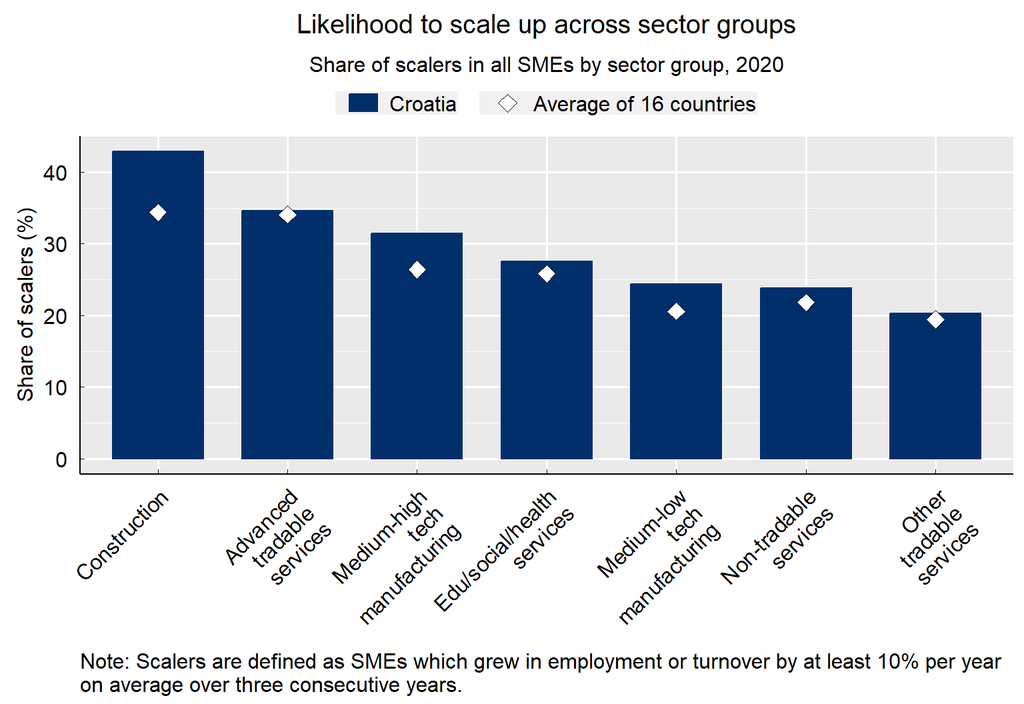

### SMEs across all size classes scale up

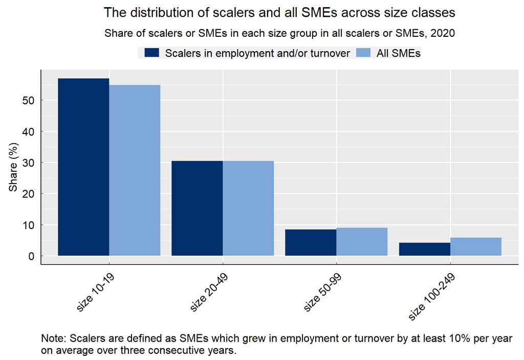

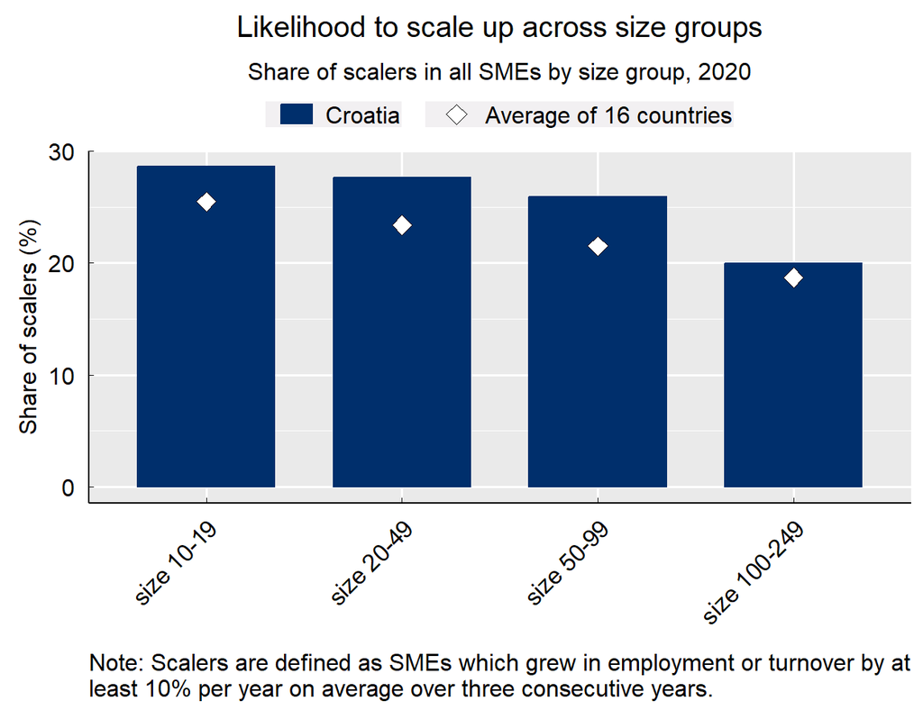

### Most of Croatian scalers are mature SMEs

Most Croatian scalers (53%) are mature SMEs that are more than 10 years old. 27% of scalers are less than 6 years old (i.e. young) and the rest (20%) are between 6 and 10 years old. Young SMEs have a higher likelihood to scale up than mature SMEs. This results in scalers being overall younger than other SMEs. The share of young scalers in all scalers is 8 percentage higher than the share of young (non-scaler) SMEs, while the share of mature scalers is 11 percentage points lower. However, six out of 10 SMEs are mature firms, which explains why the majority of scalers are not young.

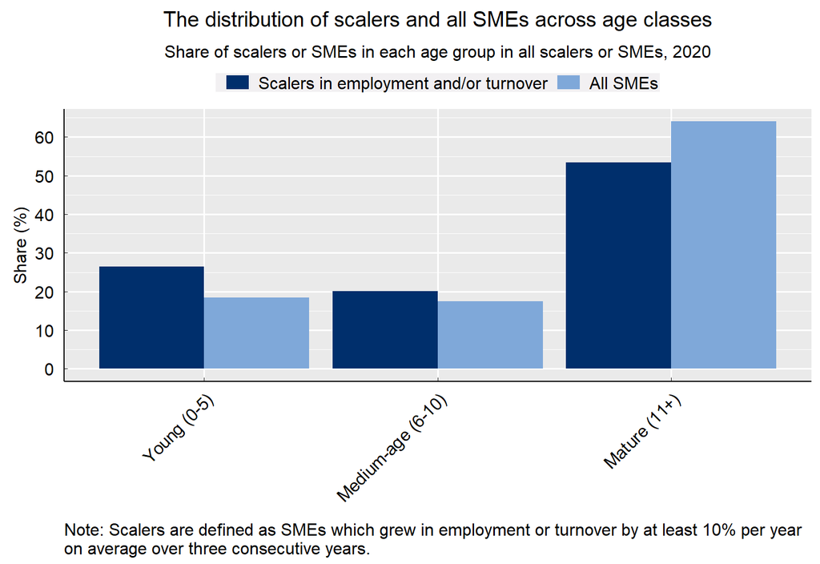

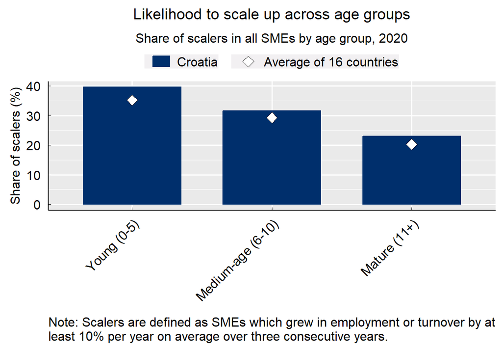

### SMEs in remote areas are as likely to scale up as SMEs in metropolitan areas

More than half of Croatian scalers are located in (large) metropolitan regions. However, SMEs in non-metropolitan region show the same likelihood to scale up than SMEs in metropolitan regions, as the distribution of scalers and other SMEs is very similar across typologies of regions. This indicates that SME proximity to metropolitan regions does not significantly influence its scaling up potential.

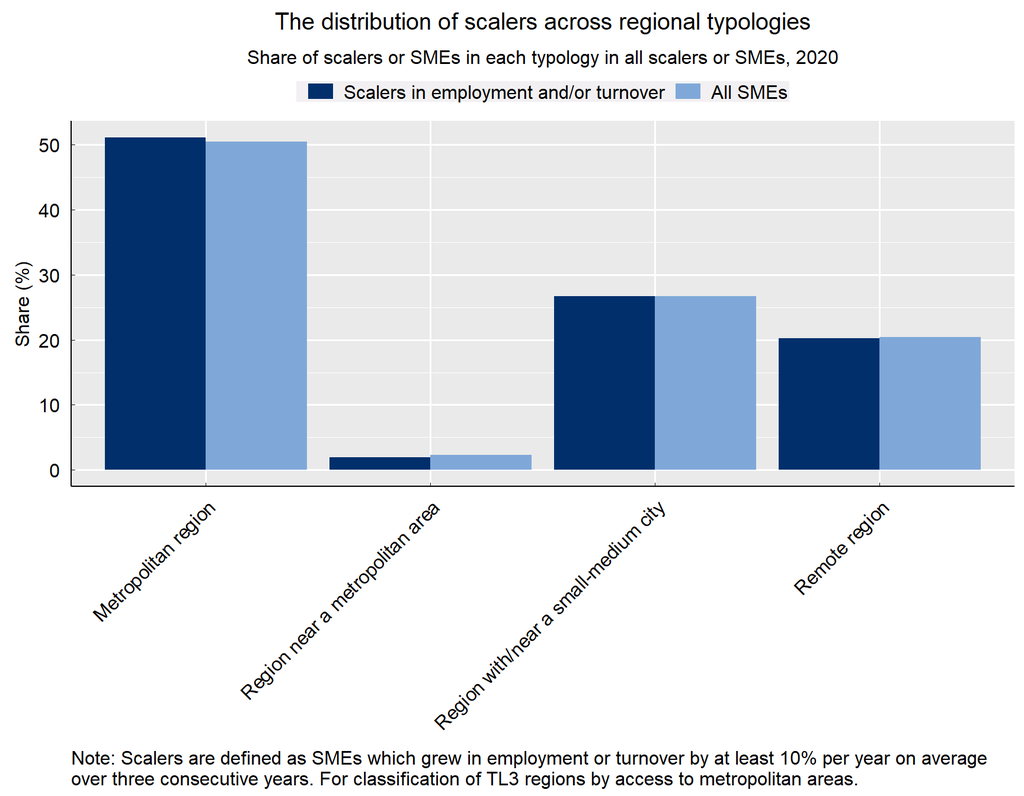

The OECD metropolitan/non-metropolitan typology for small regions (TL3) helps assess differences in socio-economic trends in regions by controlling for the presence/absence of metropolitan areas and the extent to which the latter is accessible by the population living in each region. TL3 regions are classified as “metropolitan” if more than half of their population lives in a functional urban area (FUA) of at least 250 000 inhabitants and as “non-metropolitan” otherwise. A “metropolitan region” becomes a “large metropolitan region” if the FUA accounting for more than half of the regional population has over 1.5 million inhabitants. The typology further classifies “non-metropolitan” regions based on the size of the FUA that is most accessible to the regional population. More specifically, “non-metropolitan” TL3 regions are subclassified into three possible types: i) with access to a metropolitan area, if at least half of the regional population can reach an FUA of at least 250 000 inhabitants within a 60-minute car ride; ii) With access to a small/medium city, if at least half of the regional population can reach an FUA of between 50 000 and 250 000 inhabitants within a 60-minute car ride; iii) remote, if reaching the closest FUA by car takes more than 60 minutes for more than half of the regional population.

Source: Fadic, M., et al. (2019), ‘Classifying small (TL3) regions based on metropolitan population, low density and remoteness’, OECD Regional Development Working Papers, No. 2019/06, OECD Publishing, Paris, https://doi.org/10.1787/b902cc00-en

At 28%, the likelihood for Croatia SMEs to scale up in metropolitan regions is only marginally higher than in remote regions (27%). This indicates that SME proximity to metropolitan regions is not a strong predictor of their scaling up potential, in Croatia as well as in most other countries.

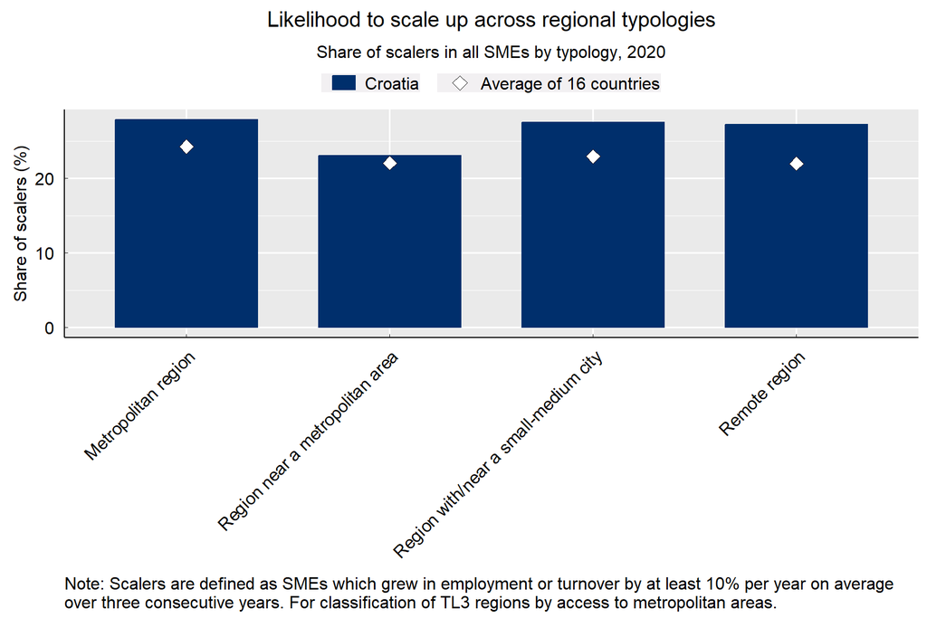

## Growth trajectories

*While many SMEs consolidate at their new size after scaling up, rapid growth also brings new challenges, with some scalers failing to adapt. This section illustrates the growth trajectories of scalers in the three years following their (first) expansion phase.*

### The majority of scalers maintained their new size or even continued to grow

In addition, 44% of scalers in employment and 40% of scalers in turnover maintained their size or grew moderately in the following three years. The share of scalers that consolidated at the new size or continued growing was closely aligned with the cross-country average.

### 5% of scalers was inactive three years after scaling up

For 5% of scalers in employment and 6% of scalers in turnover, there was no information available on their employment or turnover levels in 2019. This lack of information is open to different interpretations. First, the firm may be closed or about to close, which in most cases indicates that the business has not been successful. Second, the company may have been acquired by another entity, which often indicates success rather than failure. Third, the lack of information may simply be a “nuisance” in the data, e.g. due to reporting errors. It is not possible to know the exact incidence of each of the three alternatives. However, it is known that acquisitions are rare events even for growth-oriented businesses. Conversely, around 8-10% of businesses close each year. Therefore, it is likely that most former scalers with missing information have ceased operations.

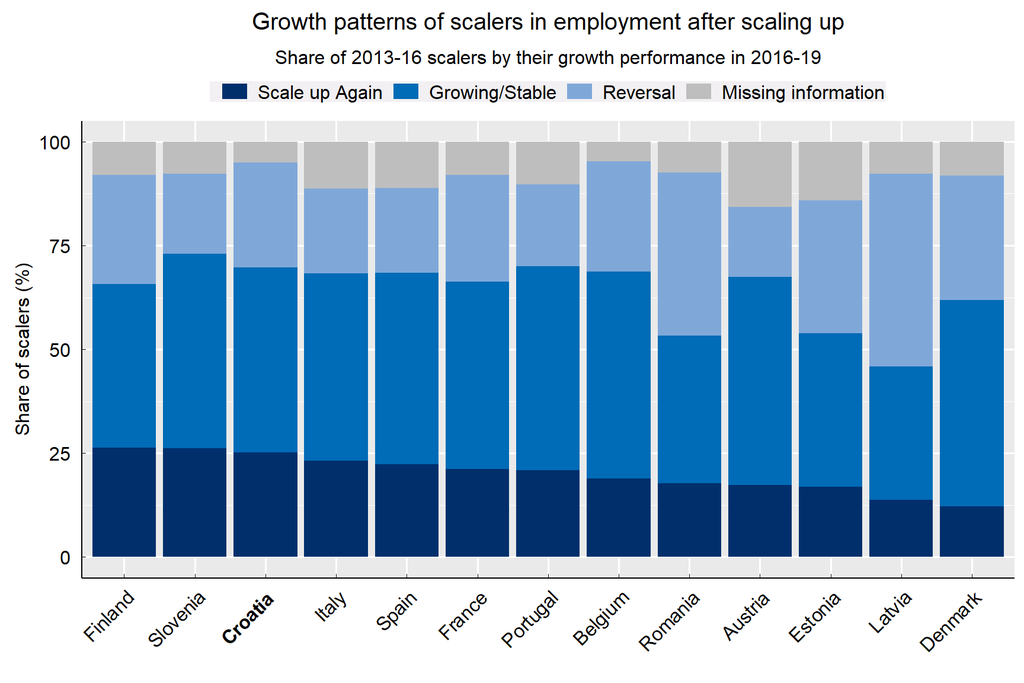

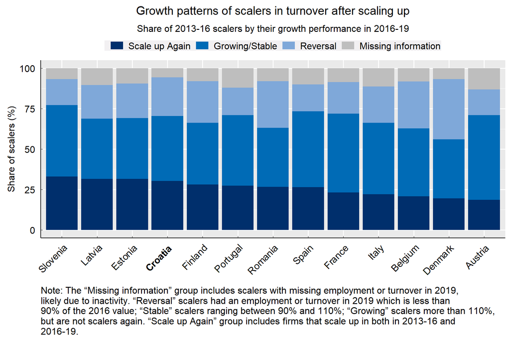